# Lecture 6：個人の履歴から好みを学ぶ

計量経済学II

Kei Ikegami

## 今日の問い

- 集団の好みの分布が分かっていても、一人の好みは分からない。
- その人の購買履歴を見ると、どんな好みがどれだけもっともらしくなるか。
- 母集団の分布も未知なら、全員の履歴から先に学ぶ。

## 一人の選択を読む

ブラックを何度も買った人は、苦味を好むかもしれない。

しかし、偶然そう選んだ可能性もある。価格や、選べた商品も履歴と一緒に見る必要がある。

## 今日の道筋

1. 母集団分布が既知：事前・尤度・事後
2. タイプの位置は既知、割合は未知：経験ベイズ
3. タイプの位置も未知：EM
4. 連続分布へ、さらに階層ベイズへ

## 同じコーヒーのモデル

苦い A の甘さ $x_A=-1$、甘い B の甘さ $x_B=1$。買わない選択肢を 0 とする。

$$u_{ijt}=1.5+\theta_i x_j-p_{jt}+\varepsilon_{ijt},\quad j=A,B.$$

同じ機会には全員に同じ価格。$\theta_i$ はその人の全機会に共通する。

## ショックと好みは違う

- $\theta_i$ は観測期間を通じて固定された甘さの好み。
- $\varepsilon_{ijt}$ は個人・選択肢・機会ごとに独立な標準Gumbelショック。
- 同じ好みでも毎回同じ選択になるわけではない。

## タイプを固定した選択確率

$$P_{jt}(\theta)=\frac{\exp(1.5+\theta x_j-p_{jt})}{1+\exp(1.5-\theta-p_{At})+\exp(1.5+\theta-p_{Bt})}.$$

買わない確率は同じ分母で分子を1にする。価格係数と定数は既知とする。

## 同じ人の履歴

$H_i$ は価格と選択の列。タイプを固定した履歴の尤度は

$$L(\theta;H_i)=\prod_{t=1}^{T_i}P_{y_{it},t}(\theta).$$

同じ人の好みを固定して確率を掛ける。まず平均してから掛けると、毎回好みを引き直す別のモデルになる。

## まず3つのタイプを仮定する

好みの候補値を $\vartheta_k$、その割合を $\pi_k$ と書く。

$$\theta_i\in\{-1.5,0,1.5\},\quad \pi=(0.25,0.50,0.25).$$

- 負は苦味好き、正は甘さ好き、0は中間。
- まず母集団の割合 $\pi$ が分かっている場合を考える。

## ベイズの公式

$$\Pr(\theta_i=\vartheta_k\mid H_i,\pi)
=\frac{\pi_k L(\vartheta_k;H_i)}{\sum_\ell\pi_\ell L(\vartheta_\ell;H_i)}.$$

事前確率 $\pi_k$ に本人の履歴の尤度を掛け、合計が1になるよう割る。

## 事前・尤度・事後

- **事前**：本人の履歴を見る前のタイプ割合。
- **尤度**：各タイプのもとで、その履歴が出る確率。
- **事後**：履歴を見た後のタイプの確率。

尤度はタイプについて合計1になる必要はない。

## データを作ってみる

400人を16機会観察する。各人のタイプを一度だけ抽選し、各機会の価格を一度だけ抽選して全員に提示する。

分析時には真のタイプを使わない。シミュレーションでは後で結果を確認できる。

## 履歴による重みの変化

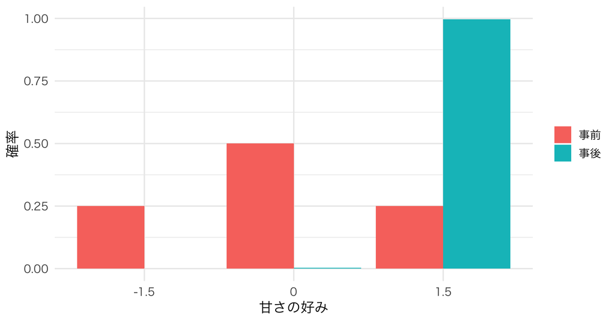

## 一つの数字にするなら

事後平均 $\sum_k w_{ik}\vartheta_k$ は、二乗誤差に対応する要約である。

事後最頻タイプ $\arg\max_k w_{ik}$ は、タイプを一つ答え、間違いを等しく数える場合の答えである。目的によって要約は違う。

## 割合も分からないとき

支点 $\vartheta_k$ を既知として、400人の履歴から $\pi$ を推定する。

$$\widehat\pi=\arg\max_{\pi_k\geq0,\,\sum_k\pi_k=1}
\sum_i\log\left[\sum_k\pi_k L(\vartheta_k;H_i)\right].$$

同じ人の履歴の確率を先に作り、その後でタイプを平均する。

## 推定したタイプの割合

| 甘さの好み | 真の割合 | 推定した割合 |
| --- | --- | --- |
| -1.5 | 0.25 | 0.281 |
| 0.0 | 0.50 | 0.448 |
| 1.5 | 0.25 | 0.271 |

真値はデータを生成した側だけが知っている。推定に使ったのは観測された価格と選択の履歴である。

## 経験ベイズ

推定した割合を固定して、本人の履歴による更新に使う。

$$\widehat w_{ik}=\frac{\widehat\pi_k L(\vartheta_k;H_i)}{\sum_\ell\widehat\pi_\ell L(\vartheta_\ell;H_i)}.$$

**集団の分布を推定し、それを使って個人の事後分布を作る**ところまでが経験ベイズである。

## 一人ずつ推定する方法もある

同じ3つの候補の中で、本人の尤度を最大にするタイプを選ぶ。

$$\widehat k_i^{\rm NP}\in\arg\max_k L(\vartheta_k;H_i).$$

これは個人別最尤（no pooling）。他人の履歴や母集団割合は使わない。

## 方法の違い

| 方法 | 個人への情報 | 何を残すか |
| --- | --- | --- |
| 個人別最尤 | 本人の尤度 | 一つのタイプ |
| 経験ベイズ | 推定した割合と本人の尤度 | タイプの事後分布 |

経験ベイズは母集団の分布が適切であるかに依存する。

## 個人の好みを要約する

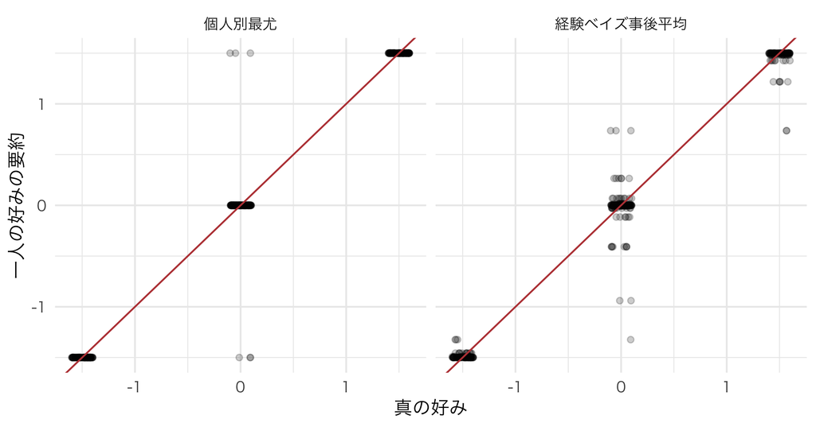

## 同じ誤差で比べる

| 方法 | 真値とのRMSE |
| --- | --- |
| 個人別最尤 | 0.184 |
| 経験ベイズ事後平均 | 0.148 |

真の係数を使った診断はシミュレーションだから可能。短い履歴では事前の影響が大きく、母集団の仮定が誤れば結果にも影響する。

## タイプの位置も未知なら

候補値（位置）$\vartheta_1,\vartheta_2,\vartheta_3$ と割合 $\pi_1,\pi_2,\pi_3$ を、全員の履歴から同時に推定する。

今回はタイプ数3を所与とする。位置の推定は、個人ごとに別々の係数を最適化することではない。

## EM：見えないタイプを交互に扱う

1. **Eステップ**：現在の位置と割合から、各人のタイプの重みを計算。
2. **Mステップ**：その重みを使って、割合と各タイプの位置を更新。
3. 対数尤度がほぼ変わらなくなるまで繰り返す。

## Eステップ：ベイズの公式を使う

反復 $r$ の候補値と割合から、一人ずつ所属確率を計算する。

$$w_{ik}^{(r)}=\frac{\pi_k^{(r)}L(\vartheta_k^{(r)};H_i)}{\sum_\ell\pi_\ell^{(r)}L(\vartheta_\ell^{(r)};H_i)}.$$

所属を一つに決めず、3タイプの重みを残す。

## Mステップ：重み付きの推定にする

Eステップで得た重みを固定して、割合と候補値を更新する。

$$\begin{aligned}
\pi_k^{(r+1)}&=\frac{1}{N}\sum_i w_{ik}^{(r)},\\
\vartheta_k^{(r+1)}&\in\arg\max_\vartheta\sum_iw_{ik}^{(r)}\log L(\vartheta;H_i).
\end{aligned}$$

重み0.7の人は、そのタイプの推定に0.7人分として参加する。

## EMの推定結果

| 推定した位置 | 推定した割合 |
| --- | --- |
| -1.504 | 0.280 |
| -0.014 | 0.446 |
| 1.458 | 0.275 |

探索範囲は $[-6,6]$。位置は小さい順に並べる。3種類の初期値から始めて結果を比べた。

## 尤度の改善を確かめる

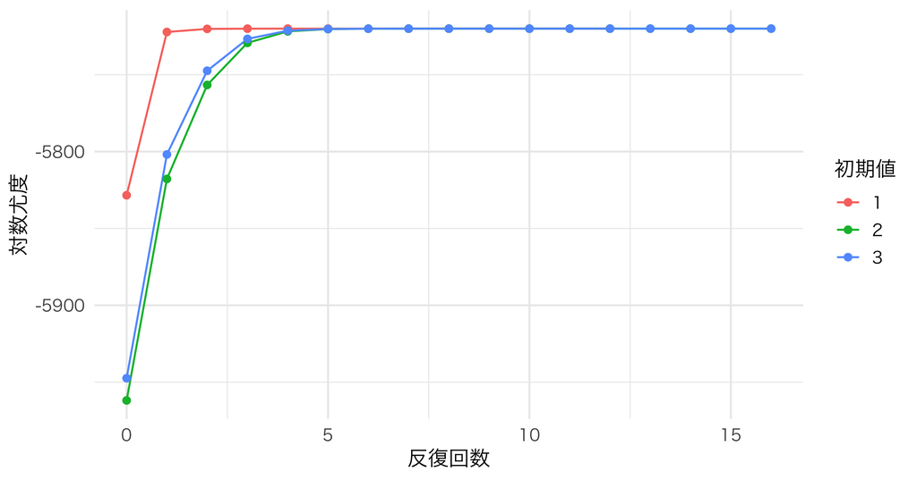

## EMの結果を読むとき

- タイプ番号を入れ替えても同じ分布：位置を順序付ける。
- 複数初期値の一致は、大域最適の証明ではない。
- タイプ数、支点の識別、母集団分布の形も仮定している。
- [Kasahara and Shimotsu (2009)](https://doi.org/10.3982/ECTA6763) は動的離散選択の有限混合で、パネルの長さなどがタイプの識別に果たす役割を分析している。今回の静的logitと同一の設定ではない。

## 好みを連続分布にする

$$\theta_i\sim N(\mu,\tau^2).$$

変えたのは甘さの好みの分布であり、価格係数ではない。同じコーヒーと同じ選択モデルを使う。

## 和を積分に置き換える

$$\ell(\mu,\tau)=\sum_i\log\int L(\theta;H_i)\frac1\tau\phi\!\left(\frac{\theta-\mu}{\tau}\right)d\theta.$$

各人の履歴を固定した $\theta$ のもとでまとめ、その後で $\theta$ を積分する。

## 連続分布の経験ベイズ

周辺尤度を最大にして $\widehat\mu,\widehat\tau$ を得る。本人の事後密度は

$$f_i^{\rm EB}(\theta\mid H_i)\propto L(\theta;H_i)\frac1{\widehat\tau}\phi\!\left(\frac{\theta-\widehat\mu}{\widehat\tau}\right).$$

logit尤度と正規分布の積は一般に正規分布ではない。ここでは数値積分する。

## 別の連続分布データを使う

200人・各8機会、真の $(\mu,\tau)=(0.2,1)$ で生成。価格は機会ごとに全員共通。

| 母集団 | 真値 | 経験ベイズの推定値 |
| --- | --- | --- |
| 平均 μ | 0.2 | 0.214 |
| 標準偏差 τ | 1.0 | 0.867 |

## 連続分布でも本人の履歴で変わる

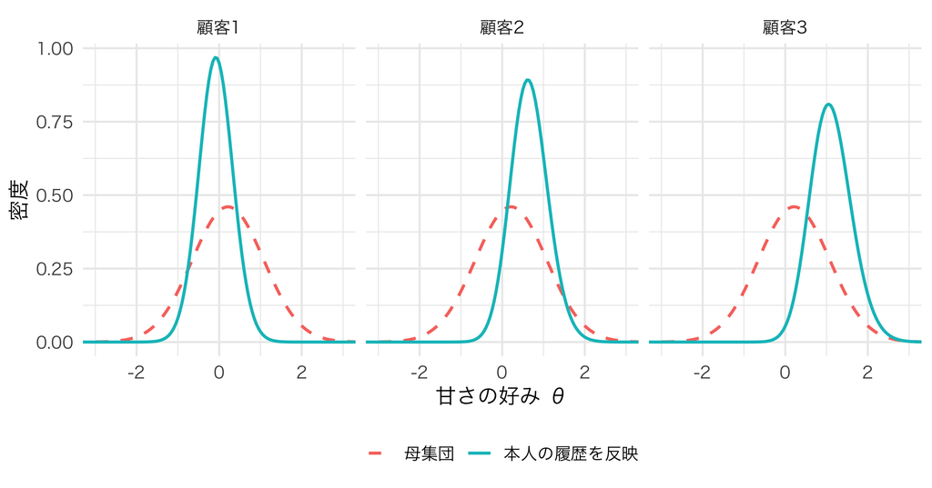

## 発展：母集団も不確実

有限タイプでも連続タイプでも、**母集団の好み → 個人の好み → 本人の履歴** という階層構造がある。

経験ベイズは推定した母集団パラメータを固定する。フルベイズはそこにも事前分布を置く。

## フルベイズで個人を更新する

$\eta=(\mu,\log\tau)$ と書けば、全員の履歴 $\mathcal H$ を使い

$$p(\theta_i\mid\mathcal H)=\int p(\theta_i\mid H_i,\eta)\,p(\eta\mid\mathcal H)\,d\eta.$$

母集団パラメータの事後分布で平均し、その不確実性を個人の分布へ伝える。

## 経験ベイズとフルベイズ

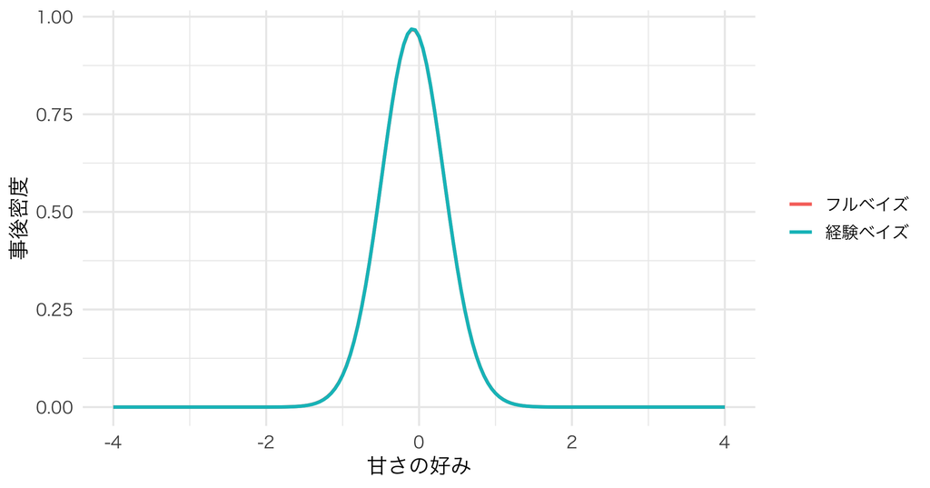

## 数値計算とモデルの確認

格子の幅・細かさを変え、端に重みが残っていないかを確かめる。事前分布や母集団の分布形状に対する感度も確認する。

好みを学んでも、企業が価格を決める内生性や、過去の購入が好みを変える可能性は自動的には解決しない。

## 今日のまとめ

- 個人の好みは、事前分布を本人の履歴の尤度で更新して考える。
- 経験ベイズは、集団の分布を推定してから個人を更新する。
- 未知の有限支点はEMで扱え、連続分布では和が積分になる。
- フルベイズは母集団パラメータの不確実性も考慮する。

## 次回：データを意思決定に使う

ターゲティング・顧客価値・コンジョイントを、意思決定の目的から考える。

目的に必要な量を定め、その量を知るためのデータとモデルを選ぶ。第7回の講義